# CM3015 Machine Learning And Neural Networks - End of Term Coursework

This machine learning excersie follows the follows the 'The universal workflow of machine learning' process from François Chollet's book, 'Deep Learning with Python' (second edition).

## 1. Defining the problem and assembling a dataset

### 1.1 Frame the problem

### Customer research with Machine Learning

I would like to learn more about the customers' behaviour and try to predict CLV with machine learning regression:

**Customer Lifetime Value (CLV):** Estimate the future value of customers over their lifetime based on their historical spending patterns and interactions with the company

```python
# Use seaborn for pairplot.
!pip install -q seaborn
import matplotlib.pyplot as plt
import numpy as np
import pandas as pd
import seaborn as sns
import tensorflow as tf

from tensorflow import keras
from keras import layers

print(tf.__version__)
```

```
2.13.0
```

### 1.2 Collect the dataset

The dataset I use is from kaggle.com.

It contains information about visitors, visits and purchases from a shop that has a store, a website and a catalog. The data includes basic information about the customer, such as birth year, education level, marital status or household income, etc. It also contains information about their purchasing behaviour, such as how much they had spent on different categories (Wine, Meat, Sweets, etc.) and how many times they purchased through different channels (store, web, catalog).

Source: https://www.kaggle.com/datasets/imakash3011/customer-personality-analysis

I also used this tutorial to get a practical example of regression with TensorFlow: https://www.youtube.com/watch?v=-vHQub0NXI4

```python
#read the data from file
df = pd.read_csv('sample_data/ecommerce2.csv')

print(df.head())
```

```
     ID  Year_Birth   Education Marital_Status    Income  Kidhome  Teenhome  \
0  9432        1977  Graduation       Together  666666.0        1         0
1  1503        1976         PhD       Together  162397.0        1         1
2  1501        1982         PhD        Married  160803.0        0         0
3  5336        1971      Master       Together  157733.0        1         0
4  8475        1973         PhD        Married  157243.0        0         1

  Dt_Customer  Recency  MntWines  ...  NumWebVisitsMonth  AcceptedCmp3  \
0    28.08.20      830         9  ...                  6             0
1    21.04.20      474        85  ...                  1             0
2    23.02.20      169        55  ...                  0             0
3    08.11.22      196        39  ...                  1             0
4    31.08.20      860        20  ...                  0             0

   AcceptedCmp4  AcceptedCmp5  AcceptedCmp1  AcceptedCmp2  Complain  \
0             0             0             0             0         0
1             0             0             0             0         0
2             0             0             0             0         0
3             0             0             0             0         0
4             0             0             0             0         0

   Z_CostContact  Z_Revenue  Response
0              3         11         0
1              3         11         0
2              3         11         0
3              3         11         0
4              3         11         0

[5 rows x 29 columns]
```

### 1.3 Understand the data

According to the book, before we "start training models, we should explore and visualize our data to gain insights about what makes it predictive, which will inform feature engineering and screen for potential issues."

#### 1.3.1 Plot histograms

I plotted some histograms just to have a generic overview of the data.

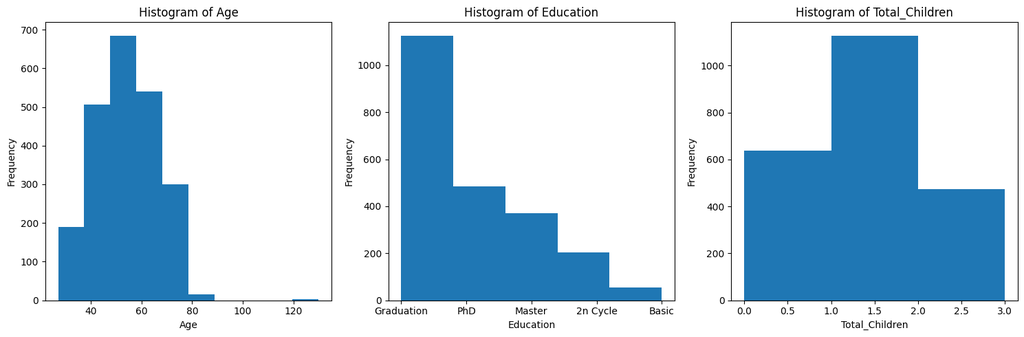

```python
from datetime import datetime

current_year = datetime.now().year
# calculate current age of customers and add it to the dataframe
df['Age'] = current_year - df['Year_Birth']

#visualise the demographics from the table: Age, Education, Kids in the household

# create a new column "Total_Children" by adding together "Kidhome" and "Teenhome"
df['Total_Children'] = df['Kidhome'] + df['Teenhome']

import matplotlib.pyplot as plt

# select columns
columns_to_plot = ['Age', 'Education', 'Total_Children']
bins = [10, 5, 3]

# create a figure with subplots
fig, axes = plt.subplots(1, len(columns_to_plot), figsize=(15, 5))

# iterate through columns and create histograms
for i, (column, num_bins) in enumerate(zip(columns_to_plot, bins)):
    axes[i].hist(df[column], bins=num_bins)

    # add labels and title for each subplot
    axes[i].set_xlabel(column)
    axes[i].set_ylabel('Frequency')
    axes[i].set_title(f'Histogram of {column}')

# adjust spacing between subplots
plt.tight_layout()

# show the figure
plt.show()
```

#### Time period covered

```python
# convert the 'Dt_Customer' column to a datetime object
df['Dt_Customer'] = pd.to_datetime(df['Dt_Customer'])

# calculate summary statistics
min_registration_date = df['Dt_Customer'].min()
max_registration_date = df['Dt_Customer'].max()
registration_date_range = max_registration_date - min_registration_date

print("Minimum Registration Date:", min_registration_date)
print("Maximum Registration Date:", max_registration_date)
print("Registration Date Range:", registration_date_range)
```

```
Minimum Registration Date: 2020-01-01 00:00:00
Maximum Registration Date: 2023-12-08 00:00:00
Registration Date Range: 1437 days 00:00:00
```

#### 1.3.2 Check for missing values

```python
missing_values = df.isnull()

# sum the missing values for each column
missing_counts = missing_values.sum()

# print missing value counts
print("Missing Value Counts:")
print(missing_counts)

# filter the dataframe to select rows where "Income" is missing
#rows_with_missing_income = df[df['Income'].isna()]

# print the rows with missing values
#print(rows_with_missing_income)
```

```
Missing Value Counts:
ID                      0
Year_Birth              0
Education               0
Marital_Status          0
Income                 24
Kidhome                 0
Teenhome                0
Dt_Customer             0
Recency                 0
MntWines                0
MntFruits               0
MntMeatProducts         0
MntFishProducts         0
MntSweetProducts        0
MntGoldProds            0
NumDealsPurchases       0
NumWebPurchases         0
NumCatalogPurchases     0
NumStorePurchases       0
NumWebVisitsMonth       0
AcceptedCmp3            0
AcceptedCmp4            0
AcceptedCmp5            0
AcceptedCmp1            0
AcceptedCmp2            0
Complain                0
Z_CostContact           0
Z_Revenue               0
Response                0
Age                     0
Total_Children          0
dtype: int64
```

There are 24 missing values in the 'Income' column. We can use machine learning to estimate these values from the other 2216 rows that are complete. Age and education level are useful features to predict income. (I will not use income for the CLV predictions in this excercise, but for a different approach, it could be useful to complete the dataset. I could also delete these rows.)

```python
from sklearn.linear_model import LinearRegression
from sklearn.model_selection import train_test_split
from sklearn.preprocessing import OneHotEncoder
from sklearn.compose import ColumnTransformer
from sklearn.pipeline import Pipeline

# separate dataset into complete data and data with missing income
complete_data = df[df['Income'].notnull()]
eligible_missing_data = df[df['Income'].isnull() & df['Age'].notnull() & df['Education'].notnull()]


# check if there is any missing data to predict
if not eligible_missing_data.empty:
    # select features and target variable
    X = complete_data[['Age', 'Education']]
    y = complete_data['Income']

    # split data into training and validation sets
    X_train, X_val, y_train, y_val = train_test_split(X, y, test_size=0.2, random_state=42)

    # define a preprocessor for encoding categorical variables (Education)
    preprocessor = ColumnTransformer(
        transformers=[
            ('edu', OneHotEncoder(), ['Education'])
        ],
        remainder='passthrough'
    )

    # create a pipeline with preprocessing and linear regression
    pipeline = Pipeline([
        ('preprocessor', preprocessor),
        ('regressor', LinearRegression())
    ])

    # train the model
    pipeline.fit(X_train, y_train)

    # make predictions for the missing income values
    eligible_missing_data_copy = eligible_missing_data.copy()
    eligible_missing_data_copy['Income'] = pipeline.predict(eligible_missing_data_copy[['Age', 'Education']]).astype(int)

    print('Rows with estimated income values completed: ')
    print(eligible_missing_data_copy)

    # replace the original dataframe with the updated one
    df.update(eligible_missing_data_copy)

# if missing_data is empty, no predictions are made, and the original dataframe remains unchanged.
```

```
Rows with estimated income values completed:
         ID  Year_Birth   Education Marital_Status  Income  Kidhome  Teenhome  \
2216   1612        1981         PhD         Single   52013        1         0
2217   5250        1943      Master          Widow   59249        0         0
2218   9235        1957  Graduation         Single   55784        1         1
2219   5798        1973      Master       Together   51610        0         0
2220   2863        1970  Graduation         Single   52474        1         2
2221  10339        1954      Master       Together   56448        0         1
2222   5255        1986  Graduation         Single   48400        1         0
2223   8996        1957         PhD        Married   58124        2         1
2224   3117        1955  Graduation         Single   56294        0         1
2225   7187        1969      Master       Together   52629        1         1
2226   8557        1982  Graduation         Single   49419        1         0
2227   1994        1983  Graduation        Married   49164        1         0
2228  10629        1973    2n Cycle        Married   47357        1         0
```

[output cut: 91 more lines]

#### 1.3.3 Print the number of instances

This step is not needed because it is a regression task, not classification.

## 2. Choose a measure of success

**Mean Absolute Error (MAE)**

The MAE is the difference between the actual and predicted value, divided by the total number of points in the dataset. A lower value indicates better model performance. The closer the MAE is to 0, the better the model's predictions align with the true values.

**Modell loss**

A measure that quantifies how well a machine learning model's predictions align with the actual values in the training data or validation data. The loss is a single scalar value that represents the error or discrepancy between the predicted values and the true values for a set of data points.

## 3. Decide on an evaluation protocol

I choose K-fold cross-validation because:

- historical CLV is available for a limited period, between 2020-01-01 and 2023-12-08. K-fold cross-validation helps make the most of the available data by partitioning it into training and validation sets multiple times, allowing assessment of model performance more robustly.
- Cross-validation helps evaluate how well the model generalizes to unseen data by simulating different data splits, which can help identify overfitting or underfitting issues.

## 4. Preparing the data

Calculate historical CLV

There are different opinions and formulas out there how to calculate the customer lifetime value, I used this one from Gartner.com: https://www.gartner.com/en/digital-markets/insights/what-is-customer-lifetime-value

```python
# calculate the annual purchases
df['Total Purchases'] = df['NumDealsPurchases'] + df['NumWebPurchases'] + df['NumCatalogPurchases'] + df['NumStorePurchases']
total_years = (pd.to_datetime(df['Dt_Customer']).max() - pd.to_datetime(df['Dt_Customer']).min()).days / 365
df['Annual Purchases'] = df['Total Purchases'] / total_years

# calculate the annual purchase amount
df['Total Spending'] = df['MntWines'] + df['MntFruits'] + df['MntMeatProducts'] + df['MntFishProducts'] + df['MntSweetProducts'] + df['MntGoldProds']
df['Annual Purchase Amount'] = df['Total Spending'] / total_years

# calculate the length of commercial relationship
current_year = pd.to_datetime('now').year
df['Year_Birth'] = current_year - df['Year_Birth']
df['Length of Commercial Relationship'] = current_year - pd.to_datetime(df['Dt_Customer']).dt.year

# calculate the historical CLV for each customer
df['Historical_CLV'] = (df['Annual Purchases'] + df['Annual Purchase Amount']) * df['Length of Commercial Relationship']

print(df.head())
```

```
       ID  Year_Birth   Education Marital_Status    Income  Kidhome  Teenhome  \
0  9432.0        46.0  Graduation       Together  666666.0      1.0       0.0
1  1503.0        47.0         PhD       Together  162397.0      1.0       1.0
2  1501.0        41.0         PhD        Married  160803.0      0.0       0.0
3  5336.0        52.0      Master       Together  157733.0      1.0       0.0
4  8475.0        50.0         PhD        Married  157243.0      0.0       1.0

  Dt_Customer  Recency  MntWines  ...  Z_Revenue  Response   Age  \
0  2020-08-28    830.0       9.0  ...       11.0       0.0  46.0
1  2020-04-21    474.0      85.0  ...       11.0       0.0  47.0
2  2020-02-23    169.0      55.0  ...       11.0       0.0  41.0
3  2022-08-11    196.0      39.0  ...       11.0       0.0  52.0
4  2020-08-31    860.0      20.0  ...       11.0       0.0  50.0

   Total_Children  Total Purchases  Annual Purchases  Total Spending  \
0             1.0             11.0          2.794015            62.0
1             2.0              1.0          0.254001           107.0
2             0.0             44.0         11.176061          1717.0
3             1.0              2.0          0.508003            59.0
4             1.0             37.0          9.398051          1608.0

   Annual Purchase Amount  Length of Commercial Relationship  Historical_CLV
0               15.748086                                  3       55.626305
1               27.178149                                  3       82.296451
2              436.120390                                  3     1341.889353
3               14.986082                                  1       15.494085
4              408.434238                                  3     1253.496868

[5 rows x 37 columns]
```

- Label encoding
- feature selection
- feature normalization
- split data into training and testing sets

```
0      55.626305
1      82.296451
2    1341.889353
3      15.494085
4    1253.496868
Name: Historical_CLV, dtype: float64
Plot of joint distributions of each of our features along with kernel density estimation plots
```

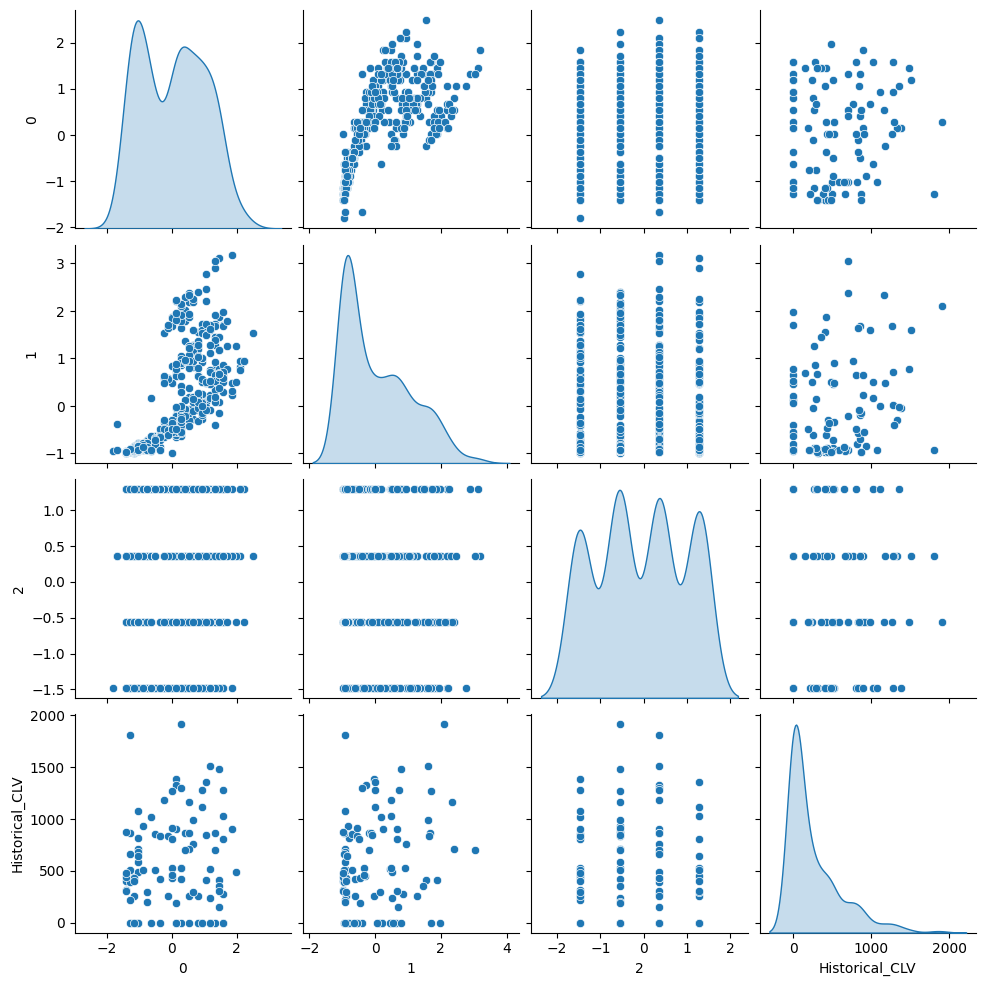

```python
from sklearn.preprocessing import StandardScaler, LabelEncoder
from sklearn.model_selection import train_test_split

# label encoding: encode categorical variables (e.g., education)
encoder = LabelEncoder()
df['Education'] = encoder.fit_transform(df['Education'])

# feature selection: split data into features (X) and CLV target (y)
#independent variables:
X = df[['Annual Purchases', 'Annual Purchase Amount', 'Length of Commercial Relationship', ]]
#dependent variable:
y = df['Historical_CLV']

# standardize/normalize features
scaler = StandardScaler()
X = scaler.fit_transform(X)

# split data into training and testing sets
X_train, X_test, y_train, y_test = train_test_split(X, y, test_size=0.2, random_state=42)


print(y.head())

import seaborn as sns
import matplotlib.pyplot as plt


X_test_df = pd.DataFrame(X_test)
y_test_df = pd.DataFrame(y_test)


# combine X_test_df and y_test_df into a single DataFrame for visualization
test_data = pd.concat([X_test_df, y_test_df], axis=1)

# display pairplot
print('Plot of joint distributions of each of our features along with kernel density estimation plots')
sns.pairplot(test_data, diag_kind='kde')
plt.show()
```

Print the a list of summary statistics

```python
!pip install tabulate
from tabulate import tabulate

mean = np.mean(X_train, axis=0)
std_dev = np.std(X_train, axis=0)
min_value = np.min(X_train, axis=0)
max_value = np.max(X_train, axis=0)


summary_data = [
    ['Mean', *mean],
    ['Standard Deviation', *std_dev],
    ['Minimum Value', *min_value],
    ['Maximum Value', *max_value]
]

# print the a list of summary statistics
table = tabulate(summary_data, headers=['Statistic'] + [f'Column {i}' for i in range(X_train.shape[1])], tablefmt='grid')
print(table)
```

```
+--------------------+-------------+------------+------------+
| Statistic          |    Column 0 |   Column 1 |   Column 2 |
+====================+=============+============+============+
| Mean               | -0.00987319 | -0.0145918 |  0.0165762 |
+--------------------+-------------+------------+------------+
| Standard Deviation |  1.00235    |  0.993221  |  0.99857   |
+--------------------+-------------+------------+------------+
| Minimum Value      | -1.93631    | -0.997813  | -1.47888   |
+--------------------+-------------+------------+------------+
| Maximum Value      |  3.79625    |  3.18743   |  1.28862   |
+--------------------+-------------+------------+------------+
```

Normalize the features so every value will fall between 0 and 1 using MinMaxScaler.

```python
from sklearn.preprocessing import MinMaxScaler

scaler = MinMaxScaler()

# fit the scaler to your training data and transform it
X_train_normalized = scaler.fit_transform(X_train)

# transform the testing data using the same scaler
X_test_normalized = scaler.transform(X_test)

# print the normalized data summary for both train and test sets
print("Normalized Train Data Summary:")
normalized_train_mean = np.mean(X_train_normalized, axis=0)
normalized_train_std_dev = np.std(X_train_normalized, axis=0)
normalized_train_min_value = np.min(X_train_normalized, axis=0)
normalized_train_max_value = np.max(X_train_normalized, axis=0)

normalized_train_summary_data = [
    ['Mean (Train)', *normalized_train_mean],
    ['Standard Deviation (Train)', *normalized_train_std_dev],
    ['Minimum Value (Train)', *normalized_train_min_value],
    ['Maximum Value (Train)', *normalized_train_max_value]
]

print(tabulate(normalized_train_summary_data, headers=['Statistic'] + [f'Column {i}' for i in range(X_train.shape[1])], tablefmt='grid'))

print("\nNormalized Test Data Summary:")
normalized_test_mean = np.mean(X_test_normalized, axis=0)
normalized_test_std_dev = np.std(X_test_normalized, axis=0)
normalized_test_min_value = np.min(X_test_normalized, axis=0)
normalized_test_max_value = np.max(X_test_normalized, axis=0)

normalized_test_summary_data = [
    ['Mean (Test)', *normalized_test_mean],
    ['Standard Deviation (Test)', *normalized_test_std_dev],
    ['Minimum Value (Test)', *normalized_test_min_value],
    ['Maximum Value (Test)', *normalized_test_max_value]
]

print(tabulate(normalized_test_summary_data, headers=['Statistic'] + [f'Column {i}' for i in range(X_test.shape[1])], tablefmt='grid'))
```

```
Normalized Train Data Summary:
+----------------------------+------------+------------+------------+
| Statistic                  |   Column 0 |   Column 1 |   Column 2 |
+============================+============+============+============+
| Mean (Train)               |   0.338664 |   0.241464 |   0.539993 |
+----------------------------+------------+------------+------------+
| Standard Deviation (Train) |   0.174343 |   0.239475 |   0.359484 |
+----------------------------+------------+------------+------------+
| Minimum Value (Train)      |   0        |   0        |   0        |
+----------------------------+------------+------------+------------+
| Maximum Value (Train)      |   1        |   1        |   1        |
+----------------------------+------------+------------+------------+

Normalized Test Data Summary:
+---------------------------+------------+------------+------------+
| Statistic                 |   Column 0 |   Column 1 |   Column 2 |
+===========================+============+============+============+
| Mean (Test)               |  0.344663  | 0.252358   |   0.510417 |
+---------------------------+------------+------------+------------+
| Standard Deviation (Test) |  0.172618  | 0.24481    |   0.362408 |
+---------------------------+------------+------------+------------+
| Minimum Value (Test)      |  0.0227273 | 0.00119048 |   0        |
+---------------------------+------------+------------+------------+
| Maximum Value (Test)      |  0.772727  | 0.999603   |   1        |
+---------------------------+------------+------------+------------+
```

## 5. Developing a model that does better than a baseline

### 5.1 Build and Train a TensorFlow Model

Define the neural network architecture using TensorFlow's Keras API:

- choose the number of layers
- choose number of neurons in each layer
- choose activation functions

```python
print("X shape:", X.shape)
print("y shape:", y.shape)
```

```
X shape: (2240, 3)
y shape: (2240,)
```

```python
import tensorflow as tf
from tensorflow import keras

my_model = tf.keras.Sequential([
    tf.keras.layers.Dense(64, activation='relu', input_shape=(X_train.shape[1],)),
    tf.keras.layers.Dense(32, activation='relu'),
    tf.keras.layers.Dense(1)
])

my_model.compile(loss='mean_squared_error', optimizer='adam', metrics=['mean_absolute_error','mean_squared_error'])

history = my_model.fit(X_train_normalized, y_train, epochs=70, batch_size=32, validation_split=0.2)
```

#### 5.1.2 Inspect the model

```
Model: "sequential_5"
_________________________________________________________________
 Layer (type)                Output Shape              Param #
=================================================================
 dense_21 (Dense)            (None, 64)                256

 dense_22 (Dense)            (None, 32)                2080

 dense_23 (Dense)            (None, 1)                 33

=================================================================
Total params: 2369 (9.25 KB)
Trainable params: 2369 (9.25 KB)
Non-trainable params: 0 (0.00 Byte)
_________________________________________________________________
```

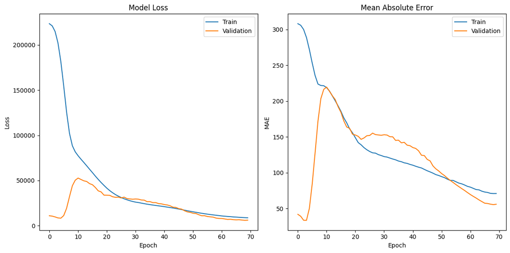

```python
my_model.summary()

fig, axs = plt.subplots(1, 2, figsize=(12, 6))

# Training & validation loss values plot
axs[0].plot(history.history['loss'], label='Training Loss')
axs[0].plot(history.history['val_loss'], label='Validation Loss')
axs[0].set_title('Model Loss')
axs[0].set_xlabel('Epoch')
axs[0].set_ylabel('Loss')
axs[0].legend(['Train', 'Validation'], loc='upper right')

# Training & validation mean absolute error values plot
axs[1].plot(history.history['mean_absolute_error'], label='Training MAE')
axs[1].plot(history.history['val_mean_absolute_error'], label='Validation MAE')
axs[1].set_title('Mean Absolute Error')
axs[1].set_xlabel('Epoch')
axs[1].set_ylabel('MAE')
axs[1].legend(['Train', 'Validation'], loc='upper right')

plt.tight_layout()
plt.show()
```

Actual vs. Predicted values:

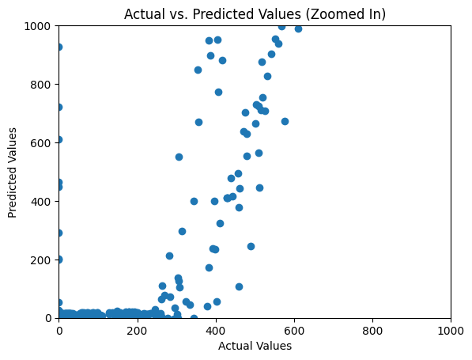

```python
y_pred = my_model.predict(X_test)

y_pred = y_pred.flatten()

# create the scatter plot, zoomed in on a specific range
plt.scatter(y_test, y_pred)
plt.xlabel('Actual Values')
plt.ylabel('Predicted Values')
plt.title('Actual vs. Predicted Values (Zoomed In)')
plt.xlim(0, 1000)
plt.ylim(0, 1000)
plt.show()
```

Error Distribution:

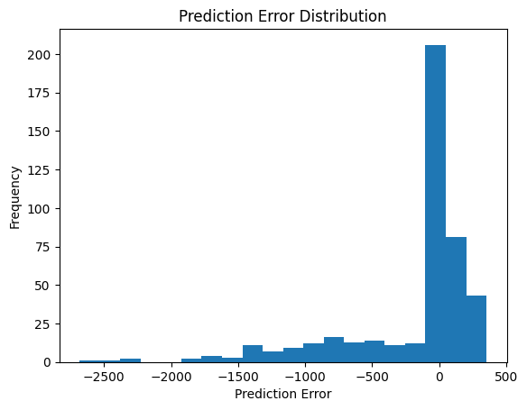

```python
y_pred = y_pred.reshape(-1)

error = y_test - y_pred
plt.hist(error, bins=20)
plt.xlabel('Prediction Error')
plt.ylabel('Frequency')
plt.title('Prediction Error Distribution')
plt.show()
```

K-fold validaton:

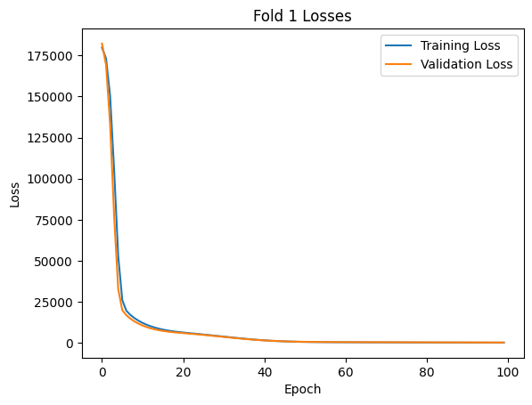

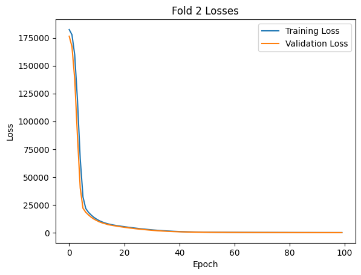

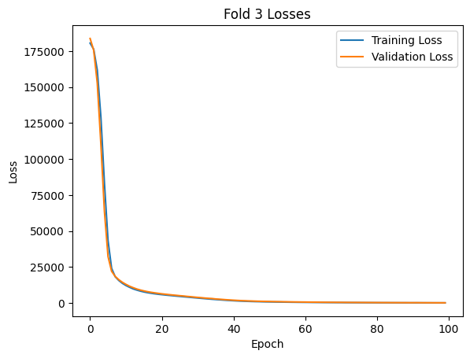

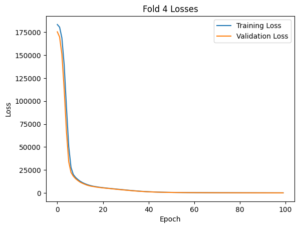

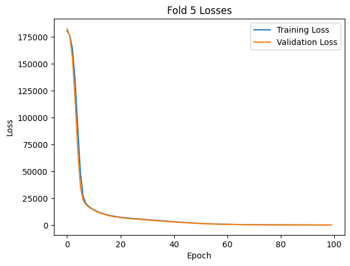

```
Mean MAE across all folds: 6.947884464263916
```

```python
import matplotlib.pyplot as plt
import numpy as np
from sklearn.model_selection import KFold

k = 5
mae_scores = []

# initialize KFold cross-validator
kf = KFold(n_splits=k, shuffle=True, random_state=42)

X = np.array(X)
y = np.array(y)

# create a list to store MAE values for each fold
mae_scores = []

# initialize a counter for fold number
fold_number = 1

# initialize lists to store training and validation losses
training_losses = []
validation_losses = []

# iterate through each fold
for train_index, val_index in kf.split(X):
    X_train_normalized, X_val = X[train_index], X[val_index]
    y_train, y_val = y[train_index], y[val_index]

    # create and compile your model
    my_model = tf.keras.Sequential([
        tf.keras.layers.Dense(64, activation='relu', input_shape=(X_train.shape[1],)),
        tf.keras.layers.Dense(32, activation='relu'),
        tf.keras.layers.Dense(1)
    ])

    my_model.compile(loss='mean_squared_error', optimizer='adam', metrics=['mean_absolute_error'])

    # train the model on the current fold
    history = my_model.fit(X_train_normalized, y_train, epochs=100, batch_size=32, validation_data=(X_val, y_val))

    # evaluate the model on the validation data for this fold
    _, mae = my_model.evaluate(X_val, y_val)
    mae_scores.append(mae)

    # append training and validation loss values to the respective lists
    training_losses.append(history.history['loss'])
    validation_losses.append(history.history['val_loss'])

    # plot training and validation loss for this fold
    plt.figure()
    plt.plot(history.history['loss'], label='Training Loss')
    plt.plot(history.history['val_loss'], label='Validation Loss')
    plt.title(f'Fold {fold_number} Losses')
    plt.xlabel('Epoch')
    plt.ylabel('Loss')
    plt.legend()
    plt.show()

    fold_number += 1

# calculate and print the mean MAE across all folds
mean_mae = np.mean(mae_scores)
print("Mean MAE across all folds:", mean_mae)
```

#### 5.1.3 Try out model

```python
y_pred = my_model.predict(X_test_normalized)
```

```python
from sklearn.metrics import mean_absolute_error, mean_squared_error, r2_score

mae = mean_absolute_error(y_test, y_pred)
mse = mean_squared_error(y_test, y_pred)
rmse = np.sqrt(mse)
r2 = r2_score(y_test, y_pred)

print(f'Mean Absolute Error: {mae}')
print(f'Mean Squared Error: {mse}')
print(f'Root Mean Squared Error: {rmse}')
print(f'R-squared (R2) Score: {r2}')
```

```
Mean Absolute Error: 257.1142127216899
Mean Squared Error: 82560.22388034024
Root Mean Squared Error: 287.3329495208307
R-squared (R2) Score: 0.30298314530006176
```

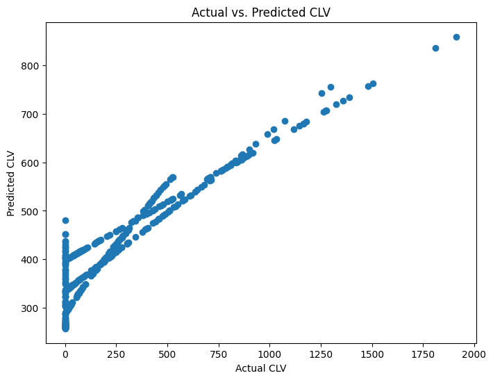

```python
import matplotlib.pyplot as plt

plt.figure(figsize=(8, 6))
plt.scatter(y_test, y_pred)
plt.xlabel('Actual CLV')
plt.ylabel('Predicted CLV')
plt.title('Actual vs. Predicted CLV')
plt.show()
```

## 6. Scaling up: developing a model that overfits

```python
# Define a model with increased complexity
overfitting_model = tf.keras.Sequential([
    tf.keras.layers.Dense(512, activation='relu', input_shape=(X_train.shape[1],)),
    tf.keras.layers.Dense(1024, activation='relu'),
    tf.keras.layers.Dense(2048, activation='relu'),
    tf.keras.layers.Dense(1)
])

# Compile the model without regularization
overfitting_model.compile(loss='mean_squared_error', optimizer='adam', metrics=['mean_absolute_error'])

# Train the model for more epochs
overfitting_history = overfitting_model.fit(X_train_normalized, y_train, epochs=200, batch_size=32, validation_split=0.2)
```

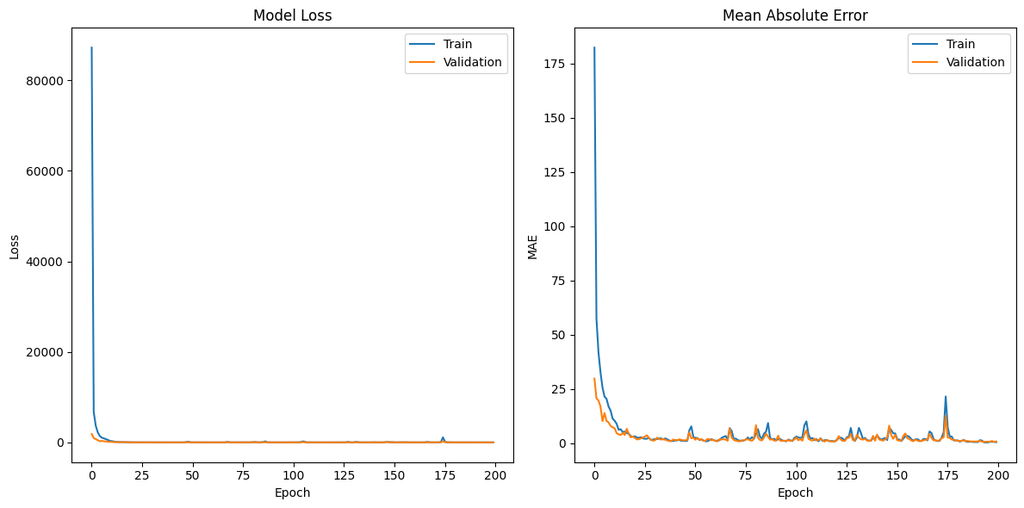

```python
#plot
fig, axs = plt.subplots(1, 2, figsize=(12, 6))

# training & validation loss values plot
axs[0].plot(overfitting_history.history['loss'], label='Training Loss')
axs[0].plot(overfitting_history.history['val_loss'], label='Validation Loss')
axs[0].set_title('Model Loss')
axs[0].set_xlabel('Epoch')
axs[0].set_ylabel('Loss')
axs[0].legend(['Train', 'Validation'], loc='upper right')

# training & validation mean absolute error values plot
axs[1].plot(overfitting_history.history['mean_absolute_error'], label='Training MAE')
axs[1].plot(overfitting_history.history['val_mean_absolute_error'], label='Validation MAE')
axs[1].set_title('Mean Absolute Error')
axs[1].set_xlabel('Epoch')
axs[1].set_ylabel('MAE')
axs[1].legend(['Train', 'Validation'], loc='upper right')

plt.tight_layout()
plt.show()
```

## 7. Regularizing model and tuning hyperparameters

Tuning hyperparameters with Keras Tuner

```python
#!pip install keras-tuner --upgrade

import keras_tuner

from kerastuner.tuners import RandomSearch
from keras.layers import Dense

# define a hyperparameter tuning function
def build_model(hp):
    model = tf.keras.Sequential()
    model.add(Dense(units=hp.Int('units1', min_value=64, max_value=512, step=64), activation='relu', input_shape=(X_train_normalized.shape[1],)))

    # add more hidden layers based on hyperparameters
    for i in range(hp.Int('num_layers', min_value=1, max_value=4)):
        model.add(Dense(units=hp.Int(f'units_{i}', min_value=64, max_value=512, step=64), activation='relu'))

    model.add(Dense(1))

    model.compile(loss='mean_squared_error', optimizer='adam', metrics=['mean_absolute_error'])

    return model

# create Keras Tuner RandomSearch tuner
tuner = RandomSearch(
    build_model,
    objective='val_loss',
    max_trials=5,  # number of hyperparameter combinations to try
    executions_per_trial=1,
    directory='my_tuner_dir'
)

# perform hyperparameter tuning
tuner.search(X_train_normalized, y_train, epochs=100, batch_size=32, validation_split=0.2)

# get the best hyperparameters
best_hp = tuner.get_best_hyperparameters(1)[0]
best_model = tuner.hypermodel.build(best_hp)
```

View results:

```python
tuner.results_summary()

trials = tuner.oracle.get_best_trials(num_trials=5)

# extract hyperparameters and validation losses
hyperparameters = [trial.hyperparameters.values for trial in trials]
validation_losses = [-trial.score for trial in trials]  # negative score for validation loss

# extract trial numbers for x-axis
trial_numbers = list(range(1, len(hyperparameters) + 1))

history = best_model.fit(X_train_normalized, y_train, epochs=50, batch_size=32, validation_split=0.2)
```

```
Results summary
Results in my_tuner_dir/untitled_project
Showing 10 best trials
Objective(name="val_loss", direction="min")

Trial 0 summary
Hyperparameters:
units1: 320
num_layers: 1
units_0: 512
Score: 9400.8935546875

Trial 2 summary
Hyperparameters:
units1: 64
num_layers: 2
units_0: 192
units_1: 64
Score: 9840.3291015625

Trial 1 summary
Hyperparameters:
units1: 192
num_layers: 1
units_0: 320
Score: 10146.1689453125

Trial 4 summary
Hyperparameters:
units1: 448
num_layers: 3
units_0: 448
units_1: 320
units_2: 256
Score: 33032.74609375

Trial 3 summary
Hyperparameters:
units1: 384
num_layers: 3
units_0: 128
units_1: 320
units_2: 64
Score: 46593.25390625
```

```
Test Loss: 84762.890625, Test Mean Absolute Error: 259.8972473144531
```

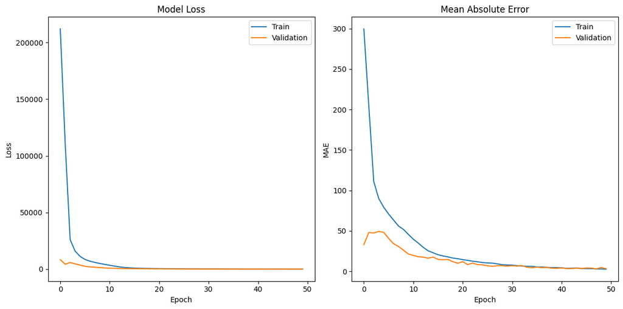

```python
# get the best hyperparameters from the tuner
best_hp = tuner.get_best_hyperparameters(1)[0]

# build a new model using the best hyperparameters
best_model = tuner.hypermodel.build(best_hp)

# compile the best model
best_model.compile(loss='mean_squared_error', optimizer='adam', metrics=['mean_absolute_error'])

# train the best model with the training data
best_history = best_model.fit(X_train_normalized, y_train, epochs=50, batch_size=32, validation_split=0.2)

# evaluate the best model on your test data
test_loss, test_mean_absolute_error = best_model.evaluate(X_test_normalized, y_test)
print(f"Test Loss: {test_loss}, Test Mean Absolute Error: {test_mean_absolute_error}")

# plot training & validation loss values
plt.figure(figsize=(12, 6))
plt.subplot(1, 2, 1)
plt.plot(best_history.history['loss'], label='Training Loss')
plt.plot(best_history.history['val_loss'], label='Validation Loss')
plt.title('Model Loss')
plt.xlabel('Epoch')
plt.ylabel('Loss')
plt.legend(['Train', 'Validation'], loc='upper right')

# plot training & validation mean absolute error values (if using MAE as a metric)
plt.subplot(1, 2, 2)
plt.plot(best_history.history['mean_absolute_error'], label='Training MAE')
plt.plot(best_history.history['val_mean_absolute_error'], label='Validation MAE')
plt.title('Mean Absolute Error')
plt.xlabel('Epoch')
plt.ylabel('MAE')
plt.legend(['Train', 'Validation'], loc='upper right')

plt.tight_layout()
plt.show()
```

A strong indication of a well-fitting model is a plot in which both the training and validation losses steadily decrease and converge at a similar point. In such cases, the model demonstrates strong performance on both the training and validation datasets.